# Welcome and Chapter 1

Author

Affiliation

Tyler George

Cornell College  
STA 363 Fall 2025 Block 3

# Welcome!

## Instructor

- Dr. Tyler George: tgeorge@cornellcollege.edu

## Course logistics

- Course Dates: October 20th to November 12th
- Course sessions: Daily, 9am-11am and 1pm-3pm
- Exam Dates: Due on October 31st and November 12th

## Generalized Linear Models

*In statistics, a generalized linear model (GLM) is a flexible generalization of ordinary linear regression. The GLM generalizes linear regression by allowing the linear model to be related to the response variable via a link function and by allowing the magnitude of the variance of each measurement to be a function of its predicted value.*

[Wikipedia](https://en.wikipedia.org/wiki/Generalized_linear_model)

. . .

**Logistic regression**

$$\begin{aligned}\pi = P(y = 1 | x) \hspace{2mm} &\Rightarrow \hspace{2mm} \text{Link function: } \log\big(\frac{\pi}{1-\pi}\big) \\
&\Rightarrow \log\big(\frac{\pi}{1-\pi}\big) = \beta_0 + \beta_1~x\end{aligned}$$

## What we’re covering this semester(1/3)

**Generalized Linear Models (Ch 1 - 6)**

- Introduce models for non-normal response variables
- Estimation, interpretation, and inference
- Mathematical details showing how GLMs are connected

## What we’re covering this semester(2/3)

**Modeling correlated data (Ch 7 - 9)**

- Introduce multilevel models for correlated and longitudinal data
- Estimation, interpretation, and inference
- Mathematical details, particularly diving into covariance structures

## What we’re covering this semester(3/3)

**More Regression Models (ITSL Chapter 7)** - Polynomial Regression - Regression Splines - Smoothing Splines - Generalized Additive Models (GAMS)

## Meet your classmates!

- Create larger groups
- Quick introductions - Name, year, and major
- Choose a reporter
  - Need help choosing? Person with birthday closest to December 1st.
- Identify 8 things everyone in the group has in common
  - Not being a Cornell Student
  - Not clothes (we’re all wearing socks)
  - Not body parts (we all have a nose)

. . .

**Reporter will share list with the class**

## What background is assumed for the course?

. . .

**Pre-reqs**

- STA 201, 202 and DSC 223

. . .

**Background knowledge**

- Statistical content
  - Linear and logistic regression
  - Statistical inference
  - Basic understanding of random variables
- Computing
  - Using R for data analysis
  - Writing reports using R Markdown or Quarto

## Course Toolkit (1/2)

- **Website**
  - https://stats-tgeorge.github.io/STA363_AdvRegF25/
  - Central hub for the course
  - Notes
  - Labs
  - Datasets

## Course Toolkit (1/2)

- **Moodle**:
  - https://moodle.cornellcollege.edu/course/view.php?id=9443
  - Submissions
  - Gradebook
  - Announcements

## Class Meetings

**Lectures**

- Lecture
- Individual and group labs
- Bring a fully-charged laptop
- Mini-projects weekly
- Exams

. . .

**Attendance is expected (if you are healthy!)**

## Textbook

[figure not shown]

*Beyond Multiple Linear Regression* by Paul Roback and Julie Legler

- Available [online](https://bookdown.org/roback/bookdown-BeyondMLR/)
- Hard copies available for purchase

## Textbook 2

The secondary text is: [An Introduction to Statistical Learning with Applications in R](https://hastie.su.domains/ISLR2/ISLRv2_corrected_June_2023.pdf.download.html) by Gareth James, Daniela Witten, Trevor Hastie, and Robert Tibshirani – it is freely available online. Chapter 7.

- Hard copies available for purchase

## Using R / RStudio

- RStudio Server is installed and should be used
- http://turing.cornellcollege.edu:8787/

## Activities & Assessments

**Readings**

- Primarily from *Beyond Multiple Linear Regression*
- Recommend reading assigned text before lecture

. . .

**Homework** - Primarily from *Beyond Multiple Linear Regression*

- Individual assignments
- Work together but must complete your own work. Discuss but don’t copy.

## Activities & Assessments

**Mini-projects**

Examples:

- Mini-project 01: Focused on models for non-normal response variables, such as count data
- Mini-project 02: Focused on models for correlated data

. . .

- Short write up and short presentation
- Team-based

## Exams

- Two exams this block, Due on October 31st and November 12th.
- Each will have two components
  - Component 1 will be on these dates and you will get a choice of oral or written format.
  - Component 2 will be a take-home, open-book, open-note, exam.
  - You will have 12 hours or more to complete this component.

## Grading

Final grades will be calculated as follows

| Category | Points |
| --- | --- |
| Homework | 300 |
| Labs & Participation | 75 |
| Mini Projects | 225 |
| Exams | 400 |
| Total | 1000 |

See Syllabus on [website](https://stats-tgeorge.github.io/STA363_AdvRegF25/) for letter grade thresholds.

## Resources

- **Office hours** to meet with your instructor in West 311
  - Typically MTWTh 3:05pm-4:05pm and by appt.
  - Double check [course calendar](https://calendar.google.com/calendar/u/0?cid=Y19hMTllMWE2M2IwOGFiNDkzYmQxNmJmNWU3MThhZmM1OWYxODIyN2EwZDhmOGQzZGMyOGRjMzE5YjQ1NmJlYjFiQGdyb3VwLmNhbGVuZGFyLmdvb2dsZS5jb20)
  - Make appointments by going to https://calendar.app.google/TQ5PNChvGmYmGyrg6
- **Email** Tyler George for private questions regarding personal matters or grades.
- College support at https://stats-tgeorge.github.io/personal_website/course-support.html.

# Chapter 1 - MLR Review

## Setup - R Packages

```r
library(tidyverse)
library(tidymodels)
library(latex2exp)
library(GGally)
library(knitr)
library(patchwork)
library(viridis)
library(ggfortify)
```

## Assumptions for linear regression

What are the assumptions for linear regression? . . .

**L**inearity: Linear relationship between mean response and predictor variable(s)

. . .

**I**ndependence: Residuals are independent. There is no connection between how far any two points lie above or below regression line.

. . .

**N**ormality: Response follows a normal distribution at each level of the predictor (or combination of predictors)

. . .

**E**qual variance: Variability (variance or standard deviation) of the response is equal for all levels of the predictor (or combination of predictors)

. . .

**Use residual plots to check that the conditions hold before using the model for statistical inference.**

## Assumptions for linear regression

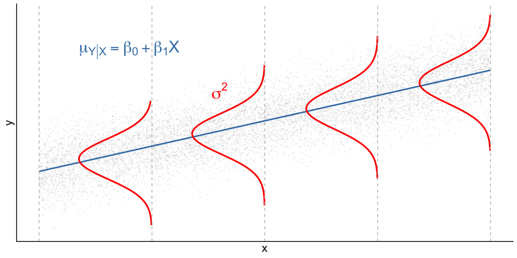

Modified from Figure 1.1. in BMLR]

- **L**inearity: Linear relationship between mean of the response $Y$ and the predictor $X$
- **I**ndependence: No connection between how any two points lie above or below the regression line
- **N**ormality: Response, $Y$, follows a normal distribution at each level of the predictor, $X$ (indicated by red curves)
- **E**qual variance: Variance (or standard deviation) of the response, $Y$, is equal for all levels of the predictor, $X$

## Questions

How do we assess these conditions?

## Beyond linear regression

- When we use linear least squares regression to draw conclusions, we do so under the assumption that L.I.N.E. are all met.
- **Generalized linear models** require different assumptions and can accommodate violations in L.I.N.E.
  - Relationship between response and predictor(s) can be nonlinear
  - Response variable can be non-normal
  - Variance in response can differ at each level of predictor(s)

. . .

**But the independence assumption must hold!**

- **Multilevel models** will be used for data with correlated observations

## Review of multiple linear regression

## Data: Kentucky Derby Winners

Today’s data is from the Kentucky Derby, an annual 1.25-mile horse race held at the Churchill Downs race track in Louisville, KY. The data is in the file derbyplus.csv and contains information for races 1896 - 2017.

. . .

**Response variable**

- `speed`: Average speed of the winner in feet per second (ft/s)]

**Predictor variables**

- `year`: Year of the race
- `condition`: Condition of the track (good, fast, slow)
- `starters`: # of horses who raced

**Additional variable**

- `winner`: Winning horse

## Data

```r
derby <- read_csv("data/derbyplus.csv")
```

```r
derby |>
  head(5) |> kable()
```

| year | winner | condition | speed | starters |
| --- | --- | --- | --- | --- |
| 1896 | Ben Brush | good | 51.66 | 8 |
| 1897 | Typhoon II | slow | 49.81 | 6 |
| 1898 | Plaudit | good | 51.16 | 4 |
| 1899 | Manuel | fast | 50.00 | 5 |
| 1900 | Lieut. Gibson | fast | 52.28 | 7 |

## Data Analysis Life Cycle

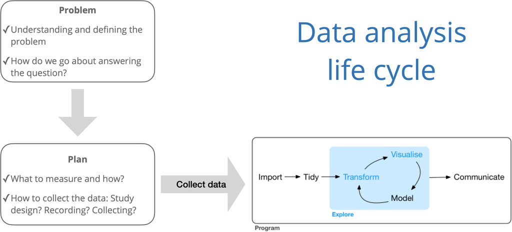

## Exploratory data analysis (EDA)

- Once you’re ready for the statistical analysis (explore), the first step should always be **exploratory data analysis**.
- The EDA will help you
  - begin to understand the variables and observations
  - identify outliers or potential data entry errors
  - begin to see relationships between variables
  - identify the appropriate model and identify a strategy
- The EDA is exploratory; formal modeling and statistical inference should be used to draw conclusions.

## Plots for univariate EDA

**Plot**

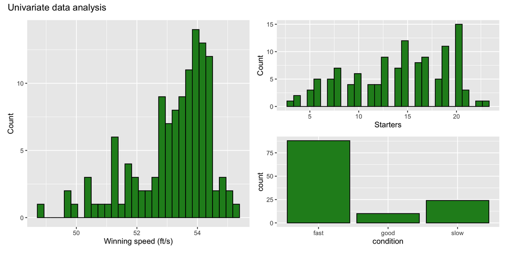

**Code**

```r
p1 <- ggplot(data = derby, aes(x = speed)) +
  geom_histogram(fill = "forestgreen", color = "black") +
  labs(x = "Winning speed (ft/s)", y = "Count")

p2 <- ggplot(data = derby, aes(x = starters)) +
  geom_histogram(fill = "forestgreen", color = "black") +
  labs(x = "Starters", y = "Count")

p3 <- ggplot(data = derby, aes(x = condition)) +
   geom_bar(fill = "forestgreen", color = "black", aes(x = ))

p1 + (p2 / p3) +
  plot_annotation(title = "Univariate data analysis")
```

## Plots for bivariate EDA

**Plot**

[figure not shown]

**Code**

```r
p4 <- ggplot(data = derby, aes(x = starters, y = speed)) +
  geom_point() +
  labs(x = "Starters", y = "Speed (ft / s)")

p5 <- ggplot(data = derby, aes(x = year, y = speed)) +
  geom_point() +
  labs(x = "Year", y = "Speed (ft / s)")

p6 <- ggplot(data = derby, aes(x = condition, y = speed)) +
  geom_boxplot(fill = "forestgreen", color = "black") +
  labs(x = "Conditions", y = "Speed (ft / s)")

(p4 + p5) + p6 +
  plot_annotation(title = "Bivariate data analysis")
```

## Scatterplot matrix

A **scatterplot matrix** helps quickly visualize relationships between many variable pairs. They are particularly useful to identify potentially correlated predictors.

. . .

**Plot**

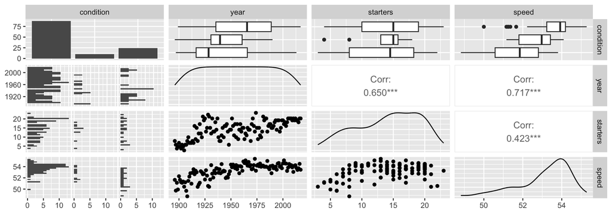

**Code**

```r
#library(GGally)
ggpairs(data = derby,
        columns = c("condition", "year", "starters", "speed"))
```

## Plots for multivariate EDA

Plot the relationship between the response and a predictor based on levels of another predictor to assess potential interactions.

**Plot**

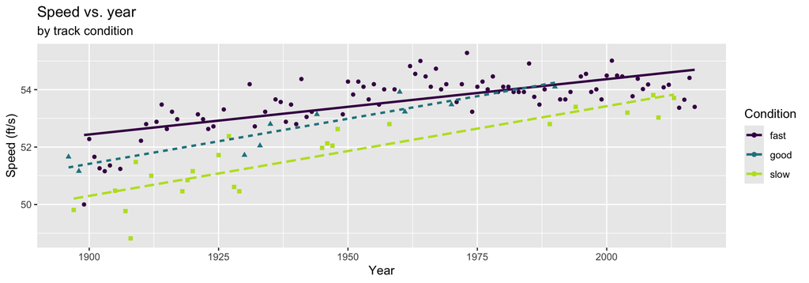

**Code**

```r
#library(viridis)
ggplot(data = derby, aes(x = year, y = speed, color = condition,
                         shape = condition, linetype = condition)) +
  geom_point() +
  geom_smooth(method = "lm", se = FALSE, aes(linetype = condition)) +
  labs(x = "Year", y = "Speed (ft/s)", color = "Condition",
       title = "Speed vs. year",
       subtitle = "by track condition") +
  guides(lty = FALSE, shape = FALSE) +
  scale_color_viridis_d(end = 0.9)
```

## Model 1: Main effects model

**Output**

| term | estimate | std.error | statistic | p.value |
| --- | --- | --- | --- | --- |
| (Intercept) | 8.197 | 4.508 | 1.818 | 0.072 |
| starters | -0.005 | 0.017 | -0.299 | 0.766 |
| year | 0.023 | 0.002 | 9.766 | 0.000 |
| conditiongood | -0.443 | 0.231 | -1.921 | 0.057 |
| conditionslow | -1.543 | 0.161 | -9.616 | 0.000 |

**Code**

```r
# Fit and display model
model1 <- lm(speed ~ starters + year + condition, data = derby)
tidy(model1) |>
  kable(digits = 3)
```

## Interpretation

$$\widehat{speed} = 8.197 - 0.005 ~ starters + 0.023 ~ year - 0.443 ~ good - 1.543 ~ slow$$

| term | estimate | std.error | statistic | p.value |
| --- | --- | --- | --- | --- |
| (Intercept) | 8.197 | 4.508 | 1.818 | 0.072 |
| starters | -0.005 | 0.017 | -0.299 | 0.766 |
| year | 0.023 | 0.002 | 9.766 | 0.000 |
| conditiongood | -0.443 | 0.231 | -1.921 | 0.057 |
| conditionslow | -1.543 | 0.161 | -9.616 | 0.000 |

. . .

1. Write out the interpretations for `starters` and `conditiongood`.
2. Does the intercept have a meaningful interpretation?

## Centering

**Centering**: Subtract a constant from each observation of a given variable

- Do this to make interpretation of model parameters more meaningful (particularly intercept)
- In STA 202, we used **mean-centering** where we subtracted the mean from each observation of given variable
- How does centering change the model?

## Centering `year`

```r
derby <- derby |>
  mutate(yearnew = year - 1896) #1896 = starting year
```

. . .

| term | estimate | std.error | statistic | p.value |
| --- | --- | --- | --- | --- |
| (Intercept) | 52.175 | 0.194 | 269.079 | 0.000 |
| starters | -0.005 | 0.017 | -0.299 | 0.766 |
| yearnew | 0.023 | 0.002 | 9.766 | 0.000 |
| conditiongood | -0.443 | 0.231 | -1.921 | 0.057 |
| conditionslow | -1.543 | 0.161 | -9.616 | 0.000 |

. . .

$$\widehat{speed} = 52.175 - 0.005 ~ starters + 0.023 ~ yearnew - 0.443 ~ good - 1.543 ~ slow$$

## Model 1: Check model assumptions

**Plots**

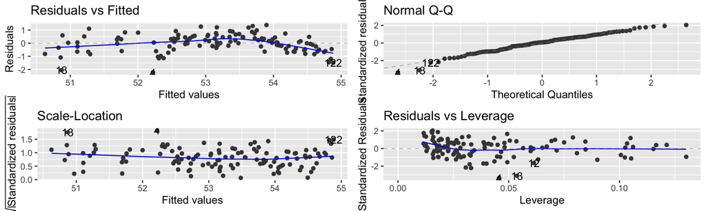

```r
#library(ggfortify)
autoplot(model1Cent)
```

**Questions**

Which of the model assumptions (LINE) does this pass and/or fail?

## Model 2: Add quadratic effect for year?

**Plot**

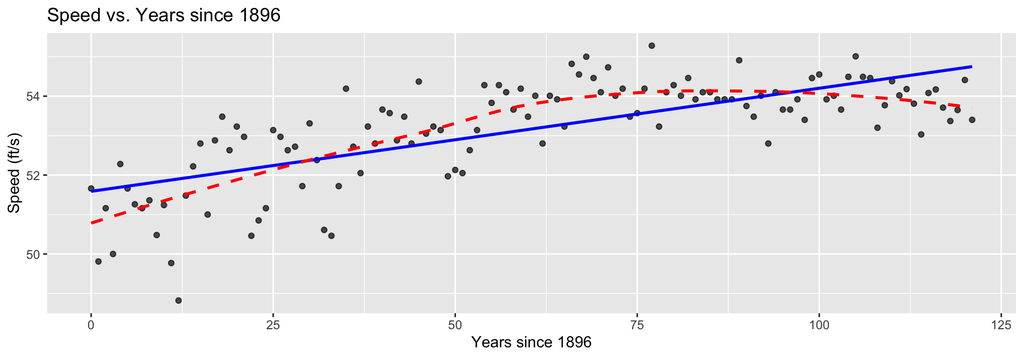

**Code**

```r
ggplot(data = derby, aes(x = yearnew, y = speed)) +
  geom_point(alpha = 0.7) +
  geom_smooth(method = "lm", se = FALSE, color = "blue") +
  geom_smooth(se = FALSE, color = "red", linetype = 2) +
  labs(x = "Years since 1896", y = "Speed (ft/s)",
       title = "Speed vs. Years since 1896")
```

## Model 2: Add $yearnew^2$

**Plot**

| term | estimate | std.error | statistic | p.value |
| --- | --- | --- | --- | --- |
| (Intercept) | 51.4130 | 0.1826 | 281.5645 | 0.0000 |
| starters | -0.0253 | 0.0136 | -1.8588 | 0.0656 |
| yearnew | 0.0700 | 0.0061 | 11.4239 | 0.0000 |
| I(yearnew^2) | -0.0004 | 0.0000 | -8.0411 | 0.0000 |
| conditiongood | -0.4770 | 0.1857 | -2.5689 | 0.0115 |
| conditionslow | -1.3927 | 0.1305 | -10.6701 | 0.0000 |

**Code**

```r
model2 <- lm(speed ~ starters + yearnew + I(yearnew^2) + condition,
             data = derby)
tidy(model2) |> kable(digits = 4)
```

## Interpreting quadratic effects

$$\hat{y} = \hat{\beta}_0 + \hat{\beta}_1 ~ x_1 + \hat{\beta}_2 ~ x_2 + \hat{\beta}_3 ~ x_2^2$$

**General interpretation**: When $x_2$ increases from a to b, $y$ is expected to change by $\hat{\beta}_2(b - a) + \hat{\beta}_3(b^2 - a^2)$, holding $x_1$ constant.

. . .

## Interpreting quadratic effects

$$\begin{aligned}\widehat{speed} = &51.413 - 0.025 ~ starters + 0.070 ~ yearnew \\
& - 0.0004 ~ yearnew^2 - 0.477 ~ good - 1.393 ~ slow\end{aligned}$$

. . .

Questions:

*Interpret the effect of year for the 5 most recent years (2013 - 2017).*

## Model 2: Check model assumptions

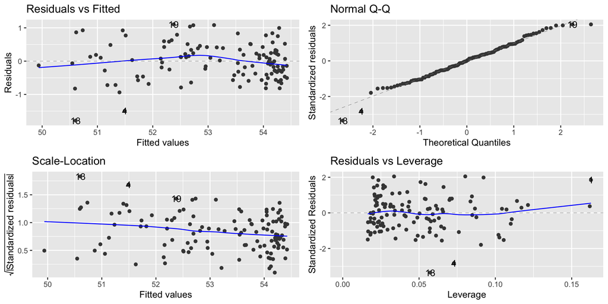

## Model 3: Include interaction term?

Recall from the EDA…

**Plot**

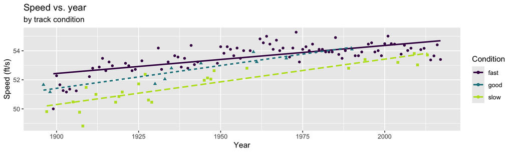

**Code**

```r
library(viridis)
ggplot(data = derby, aes(x = year, y = speed, color = condition,
                         shape = condition, linetype = condition)) +
  geom_point() +
  geom_smooth(method = "lm", se = FALSE, aes(linetype = condition)) +
  labs(x = "Year", y = "Speed (ft/s)", color = "Condition",
       title = "Speed vs. year",
       subtitle = "by track condition") +
  guides(lty = FALSE, shape = FALSE) +
  scale_color_viridis_d(end = 0.9)
```

## Model 3: Add interaction term

$$\begin{aligned}\widehat{speed} = & 52.387 - 0.003 ~ starters + 0.020 ~ yearnew - 1.070 ~ good - 2.183 ~ slow \\ &+0.012 ~ yearnew \times good + 0.012 ~ yearnew \times slow \end{aligned}$$

**Output**

[output not shown]

**Code**

```r
model3 <- lm(speed ~ starters + yearnew + condition +
               yearnew * condition,
             data = derby)
tidy(model3) |> kable(digits = 4)
```

**Assumptions**

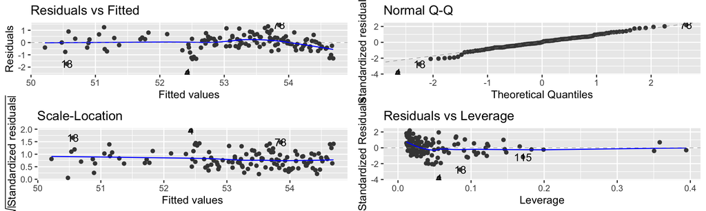

## Interpreting interaction effects

| term | estimate | std.error | statistic | p.value |
| --- | --- | --- | --- | --- |
| (Intercept) | 52.387 | 0.200 | 262.350 | 0.000 |
| starters | -0.003 | 0.016 | -0.189 | 0.850 |
| yearnew | 0.020 | 0.003 | 7.576 | 0.000 |
| conditiongood | -1.070 | 0.423 | -2.527 | 0.013 |
| conditionslow | -2.183 | 0.270 | -8.097 | 0.000 |
| yearnew:conditiongood | 0.012 | 0.008 | 1.598 | 0.113 |
| yearnew:conditionslow | 0.012 | 0.004 | 2.866 | 0.005 |

- Write out the interpretation of…

## Which model would you choose?

**Model 1: Main effects**

| r.squared | adj.r.squared | AIC | BIC |
| --- | --- | --- | --- |
| 0.73 | 0.721 | 259.478 | 276.302 |

**Model 2: Main effects + \(year^2\)**

| r.squared | adj.r.squared | AIC | BIC |
| --- | --- | --- | --- |
| 0.827 | 0.819 | 207.429 | 227.057 |

**Model 3: Main effects + interaction**

| r.squared | adj.r.squared | AIC | BIC |
| --- | --- | --- | --- |
| 0.751 | 0.738 | 253.584 | 276.016 |

**Code**

```r
# Model 1
glance(model1Cent) |>
  select(r.squared, adj.r.squared, AIC, BIC) |>
  kable(digits = 3)

# Model2
glance(model2) |>
  select(r.squared, adj.r.squared, AIC, BIC) |>
  kable(digits = 3)

# Model 3
glance(model3) |>
  select(r.squared, adj.r.squared, AIC, BIC) |>
  kable(digits = 3)
```

## What are these model quality metrics?

- **How do we define RSquared?**
- **What is adj.r.squared?**

## Measures of model performance

- $\color{#4187aa}{R^2}$: Proportion of variability in the response explained by the model.
  - Will always increase as predictors are added, so it shouldn’t be used to compare models
- $\color{#4187aa}{Adj. R^2}$: Similar to $R^2$ with a penalty for extra terms

. . .

- $\color{#4187aa}{AIC}$: Likelihood-based approach balancing model performance and complexity
- $\color{#4187aa}{BIC}$: Similar to AIC with stronger penalty for extra terms

. . .

- **Nested F Test (extra sum of squares F test)**: Generalization of t-test for individual coefficients to perform significance tests on nested models

## Which model would you choose?

Use the **`glance`** function to get model statistics.

**Output**

| model | r.squared | adj.r.squared | AIC | BIC |
| --- | --- | --- | --- | --- |
| Model1 | 0.730 | 0.721 | 259.478 | 276.302 |
| Model2 | 0.827 | 0.819 | 207.429 | 227.057 |
| Model3 | 0.751 | 0.738 | 253.584 | 276.016 |

**Code**

```r
model1_glance <- glance(model1Cent) |>
  select(r.squared, adj.r.squared, AIC, BIC)
model2_glance <- glance(model2) |>
  select(r.squared, adj.r.squared, AIC, BIC)
model3_glance <- glance(model3) |>
  select(r.squared, adj.r.squared, AIC, BIC)

model1_glance |>
  bind_rows(model2_glance) |>
  bind_rows(model3_glance) |>
  bind_cols(model = c("Model1", "Model2", "Model3")) |>
  select(model, everything()) |>
kable(digits = 3)
```

## Characteristics of a “good” final model

- Model can be used to answer primary research questions
- Predictor variables control for important covariates
- Potential interactions have been investigated
- Variables are centered, as needed, for more meaningful interpretations
- unnecessary terms are removed
- Assumptions are met and influential points have been addressed
- model tells a “persuasive story parsimoniously”

[List from Section 1.6.7 of BMLR](https://bookdown.org/roback/bookdown-BeyondMLR/)

## Inference for multiple linear regression

Use statistical inference to

- Determine if predictors are statistically significant (not necessarily practically significant!)
- Quantify uncertainty in coefficient estimates
- Quantify uncertainty in model predictions

. . .

If L.I.N.E. assumptions are met, we can conduct inference using the $t$ distribution and estimated standard errors

## Inference for regression

**When L.I.N.E. conditions are met**

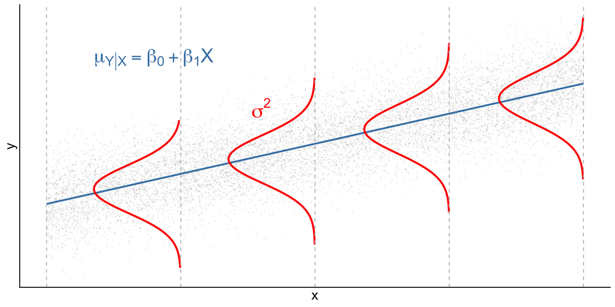

**We can**

- Use least squares regression to get the estimates $\hat{\beta}_0$, $\hat{\beta}_1$, and $\hat{\sigma}^2$
- $\hat{\sigma}$ is the **regression standard error**
- $\hat{\sigma} = \sqrt{\frac{\sum_{i=1}^n(y_i - \hat{y}_i)^2}{n - p - 1}} = \sqrt{\frac{\sum_{i=1}^n e_i^2}{n-p-1}}$

## Acknowledgements

- These slides are based on content in [BMLR: Chapter 1 - Review of Multiple Linear Regression](https://bookdown.org/roback/bookdown-BeyondMLR/ch-MLRreview.html)
- Initial versions of the slides are by Dr. Maria Tackett, Duke University